# Assignment 9

Backman

4/23/2020

## **Instructions:**

#### **All file paths should be relative, starting from the Assignment_9 directory!! (where you found this file)**

#### **This means that you need to create a new R-Project named “Assignment_9.Rproj” in your Assignment_9 directory, and work from scripts within that.**

### **For credit…**

#### 1. Push a completed version of your Rproj and R-markdown file (details at end of this assignment) to GitHub

#### 2. Your score will also depend on your analyses and presentation of your final report

### Your tasks:

- Use the data set “../../Data/GradSchool_Admissions.csv”
- You will explore and model the predictors of graduate school admission
  - the “admit” column is coded as 1=success and 0=failure
  - the other columns are the GRE score, the GPA, and the rank of the undergraduate institution, where I is “top-tier.”
- Document your data explorations, figures, and conclusions in a reproducible R-markdown report
- Upload your **self-contained** R project, including knitted report, to GitHub in *your* Assignment_9 directory

#### **Load Libraries**

```r
library(tidyverse)
library(modelr)
library(GGally)
library(lindia)
library(skimr)
library(patchwork)
library(caret)
```

#### **Load data**

```r
df <- read_csv("./GradSchool_Admissions.csv")
```

#### **Explore data**

```r
summary(df)
```

```
##      admit             gre             gpa             rank
##  Min.   :0.0000   Min.   :220.0   Min.   :2.260   Min.   :1.000
##  1st Qu.:0.0000   1st Qu.:520.0   1st Qu.:3.130   1st Qu.:2.000
##  Median :0.0000   Median :580.0   Median :3.395   Median :2.000
##  Mean   :0.3175   Mean   :587.7   Mean   :3.390   Mean   :2.485
##  3rd Qu.:1.0000   3rd Qu.:660.0   3rd Qu.:3.670   3rd Qu.:3.000
##  Max.   :1.0000   Max.   :800.0   Max.   :4.000   Max.   :4.000
```

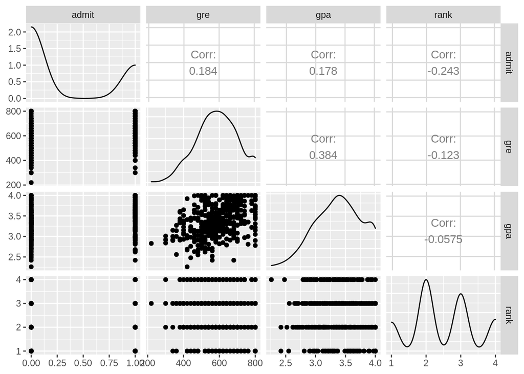

```r
df %>% ggpairs()
```

#### **Clean data**

```r
df$rank <- factor(df$rank)
df$admit <- as.logical(df$admit)
```

#### **Making models**

```r
mod1 <- glm(formula = admit ~ gre + gpa + rank, data = df, family = "binomial")
mod2 <- glm(formula = admit ~ gre * gpa * rank, data = df, family = "binomial")
```

### **Comparing models: best fit line**

```r
mod1mse <- mean(residuals(mod1)^2)
mod2mse <- mean(residuals(mod2)^2)

mod1mse ; mod2mse
```

```
## [1] 1.146294
```

```
## [1] 1.125965
```

#### The lowest number shows the best fit line model. mod2mse has the best fit line, so we will use that model.

### **Evaluating predictions**

```r
df_mod2 <- add_predictions(df, mod2, type = "response")
allmods <- gather_predictions(df, mod1, mod2)
head(allmods)
```

```
## # A tibble: 6 x 6
##   model admit   gre   gpa rank    pred
##   <chr> <lgl> <dbl> <dbl> <fct>  <dbl>
## 1 mod1  FALSE   380  3.61 3     -1.57
## 2 mod1  TRUE    660  3.67 3     -0.885
## 3 mod1  TRUE    800  4    1      1.04
## 4 mod1  TRUE    640  3.19 4     -1.53
## 5 mod1  FALSE   520  2.93 4     -2.01
## 6 mod1  TRUE    760  3    2     -0.532
```

### **Compare allmods to visually see best model**

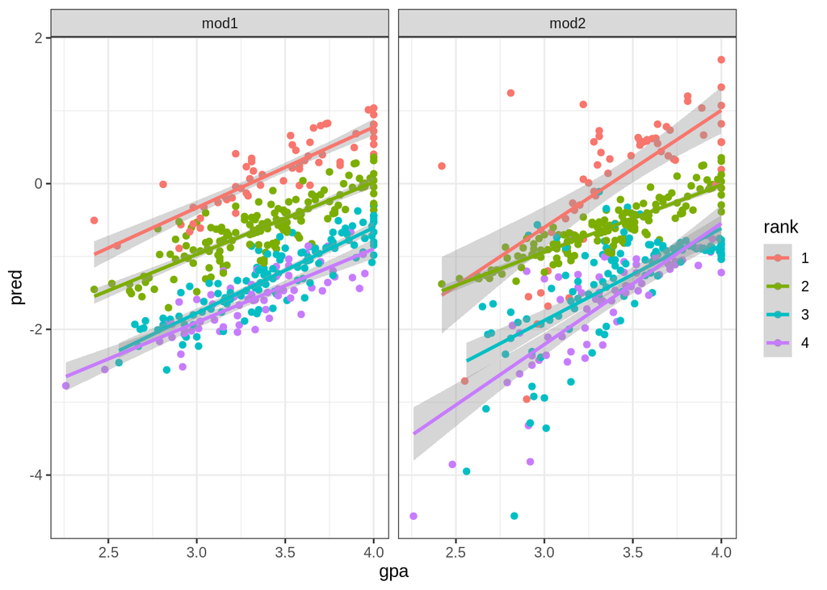

```r
ggplot(allmods,aes(x=gpa,col=rank)) +
  geom_point(aes(y=pred)) +
  geom_smooth(method = "lm", aes(y=pred)) +
  facet_wrap(~model) +
  theme_bw()
```

#### Both models seem to follow the trend, but since the line of best fit was better for mod2, we will use mod2.

### **Look at predictions for model 2**

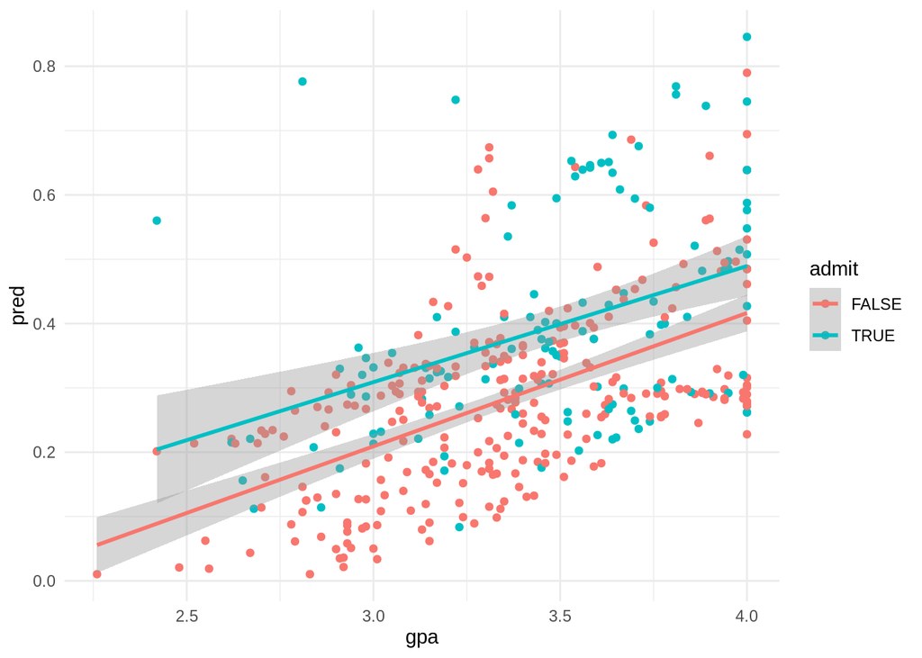

```r
p1 <- ggplot(df_mod2, aes(x=gpa, y=pred, color=admit)) + theme_minimal() +
  geom_point() + geom_smooth(method = "lm")
p1
```

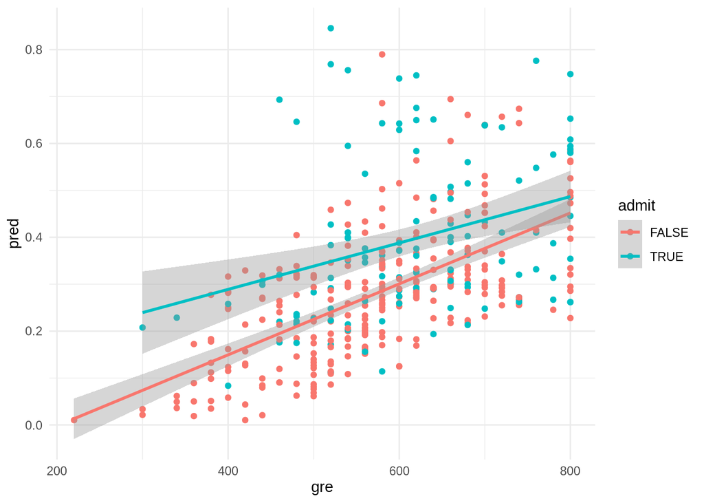

```r
p2 <- ggplot(df_mod2, aes(x=gre, y=pred, color=admit)) + theme_minimal()  +
  geom_point() + geom_smooth(method = "lm")
p2
```

#### Both gre and gpa seem to be good indicators of whether you will be admitted or not.

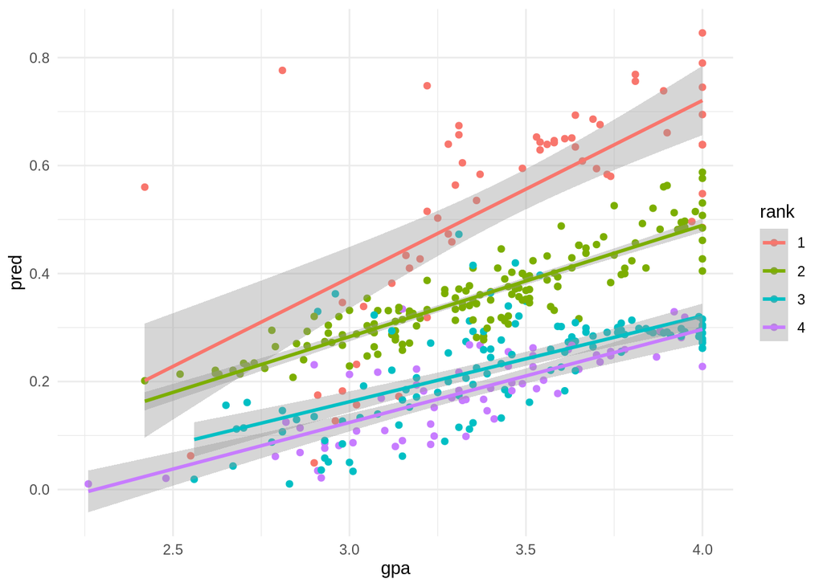

```r
p3 <- ggplot(df_mod2, aes(x=gpa, y=pred, color=rank)) + theme_minimal() +
  geom_point() + geom_smooth(method = "lm")
p3
```

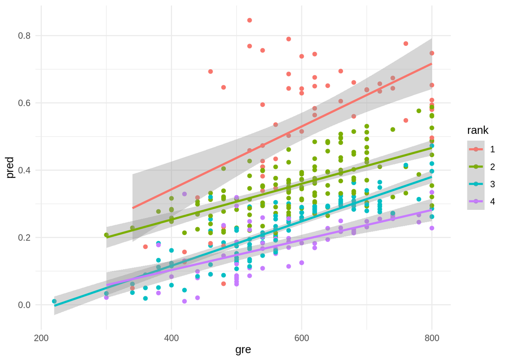

```r
p4 <- ggplot(df_mod2, aes(x=gre, y=pred, color=rank)) + theme_minimal()  +
  geom_point() + geom_smooth(method = "lm")
p4
```